# 3.2 Practical: random intercepts regression

Benjamin Rosenbaum

April 3, 2019

In the previous model, we just fitted mean values to groups and there was still some unexplained variation.

Here, we will add a continuous predictor (covariate).

Specifically, for the same dataset of fruitfly longevity and sexual activity, we add the covariate individual body size.

Lifespan is assumed to be positively correlated with body size.

# Setup

```r
rm(list=ls())
library(rstan)
library(coda)
library(BayesianTools)
setwd("~/Desktop/teaching Bayes")

rstan_options(auto_write = TRUE)
options(mc.cores = 3)
```

# Read dataset

```r
df = read.csv("data/FruitflyDataReduced.csv")
head(df)
```

```
##   Longevity CompanionNumber Thorax
## 1        35       Pregnant8   0.64
## 2        37       Pregnant8   0.68
## 3        49       Pregnant8   0.68
## 4        46       Pregnant8   0.72
## 5        63       Pregnant8   0.72
## 6        39       Pregnant8   0.76
```

```r
str(df)
```

```
## 'data.frame':    125 obs. of  3 variables:
##  $ Longevity      : int  35 37 49 46 63 39 46 56 63 65 ...
##  $ CompanionNumber: Factor w/ 5 levels "None0","Pregnant1",..: 3 3 3 3 3 3 3 3 3 3 ...
##  $ Thorax         : num  0.64 0.68 0.68 0.72 0.72 0.76 0.76 0.76 0.76 0.76 ...
```

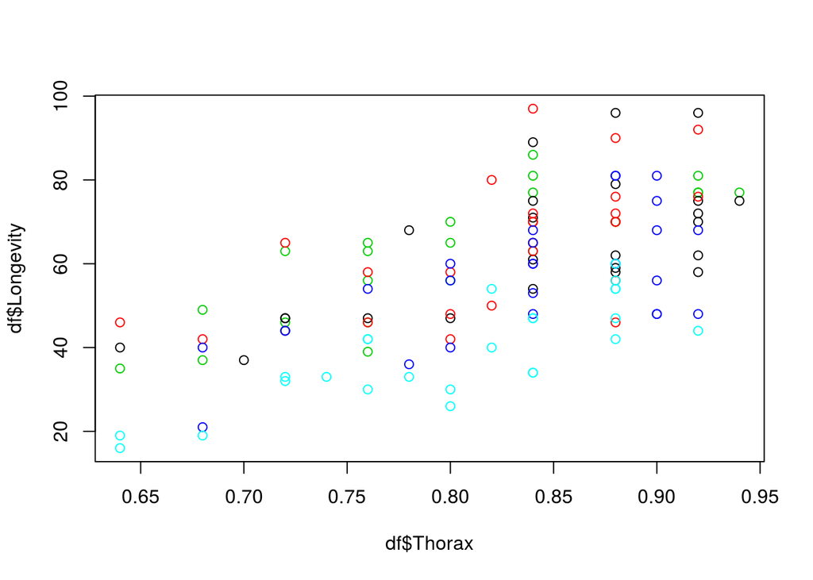

```r
plot(df$Thorax, df$Longevity, col=as.factor(df$CompanionNumber))
```

Note that the range of x-values (body size) is far away from zero. This makes intercepts on regression hard to interpret.

We will use normalized (zscore) predictor values instead.

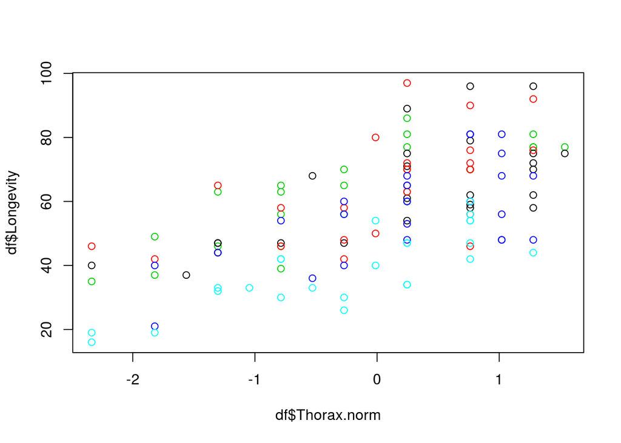

```r
df$Thorax.norm = as.numeric(scale(df$Thorax))
df$group = as.integer(df$CompanionNumber)
plot(df$Thorax.norm, df$Longevity, col=as.factor(df$CompanionNumber))
```

`as.integer(<factor>)` codes groups in alphabetical order

```r
table(df$group, df$CompanionNumber)
```

```
##
##     None0 Pregnant1 Pregnant8 Virgin1 Virgin8
##   1    25         0         0       0       0
##   2     0        25         0       0       0
##   3     0         0        25       0       0
##   4     0         0         0      25       0
##   5     0         0         0       0      25
```

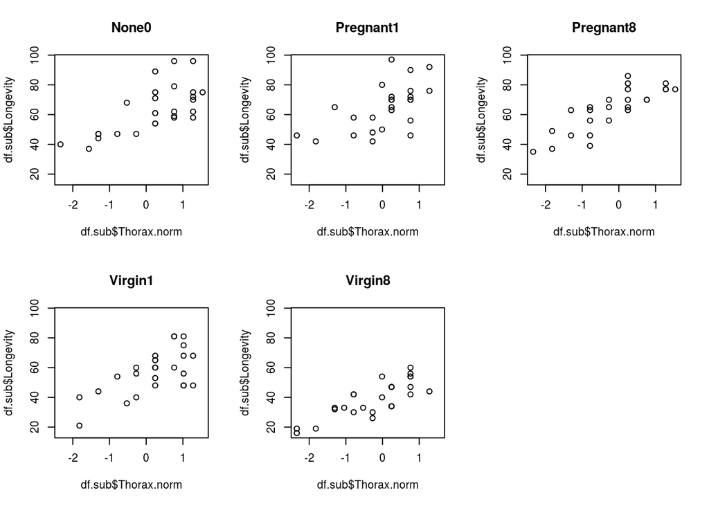

```r
par(mfrow=c(2,3))
for (i in 1:5){
  df.sub=subset(df, df$group==i)
  plot(df.sub$Thorax.norm,  df.sub$Longevity,
       xlim=range(df$Thorax.norm),
       ylim=range(df$Longevity),
       main=levels(df$CompanionNumber)[i]
  )
}
```

# Random intercepts model

We will fit linear regression lines to each group (`CompanionNumber`) as follows:

$$\begin{align}
y_i & \sim \text{normal}(a_{group_i}+b\cdot x_i, \sigma) \quad i=1,...,n\quad (n\ \text{observations}) \\
a_j & \sim \text{normal}(\mu_a, \sigma_a) \quad j=1,...,m \quad (m\ \text{groups})
\end{align}$$

Here, $a_j$ is a group-level intercept, which are allowed to vary (partial pooling). (Analogue to $\mu_j$ in the previous example)

But we assume identical slope $b$ for all groups (complete pooling).

So this is a random intercepts linear regression, lm-formulation would be `y ~ (1|group) + x`.

The approach is also similar to frequentist ANCOVA.

The Stan code differs from the previous model by adding the covariate $x$ and parameter $b$ (slope), and renaming $\mu$ to $a$, that’s it!

```r
data = list(y = df$Longevity,
            x = df$Thorax.norm,
            group = df$group,
            n = nrow(df),
            n_group = 5)

stan_code_partial = '
data {
  int n;
  int n_group;
  real y[n];
  real x[n];
  int group[n];
}
parameters {
  real a[n_group];
  real b;
  real<lower=0> sigma;
  real mu_a;
  real<lower=0> sigma_a;
}
model {
  // priors
  mu_a ~ normal(0,100);
  sigma_a ~ cauchy(0,10);
  for (j in 1:n_group){
    a[j] ~ normal(mu_a,sigma_a);
  }
  b ~ normal(0,100);
  sigma ~ normal(0,100);
  // likelihood
  for(i in 1:n){
    y[i] ~ normal(a[group[i]]+b*x[i], sigma);
  }
}
'

stan_model_partial = stan_model(model_code=stan_code_partial)
# save(stan_model_partial, file="stan_code_partial.RData")
# load("stan_code_partial.RData")

fit_partial  = sampling(stan_model_partial,
                        data=data,
                        chains=3,
                        iter=2000,
                        warmup=1000
)

print(fit_partial, digits=3, probs=c(0.025, 0.975))
```

```
## Inference for Stan model: ecca1540f8edefe7110d626e5dd12a2a.
## 3 chains, each with iter=2000; warmup=1000; thin=1;
## post-warmup draws per chain=1000, total post-warmup draws=3000.
##
##             mean se_mean    sd     2.5%    97.5% n_eff  Rhat
## a[1]      61.261   0.030 2.203   56.742   65.591  5296 1.000
## a[2]      63.856   0.033 2.184   59.486   68.016  4429 1.000
## a[3]      65.061   0.034 2.124   60.888   69.194  3908 1.000
## a[4]      54.637   0.033 2.053   50.614   58.715  3810 0.999
## a[5]      42.362   0.036 2.231   38.072   46.807  3918 0.999
## b         10.553   0.015 0.994    8.605   12.570  4304 0.999
## sigma     10.635   0.011 0.709    9.375   12.147  4091 1.000
## mu_a      57.360   0.110 5.483   46.313   68.589  2468 1.000
## sigma_a   11.356   0.108 4.961    5.576   25.050  2101 1.000
## lp__    -367.827   0.066 2.291 -373.478 -364.434  1216 1.003
##
## Samples were drawn using NUTS(diag_e) at Mon Mar 18 16:13:23 2019.
## For each parameter, n_eff is a crude measure of effective sample size,
## and Rhat is the potential scale reduction factor on split chains (at
## convergence, Rhat=1).
```

```
## ci_level: 0.8 (80% intervals)
```

```
## outer_level: 0.95 (95% intervals)
```

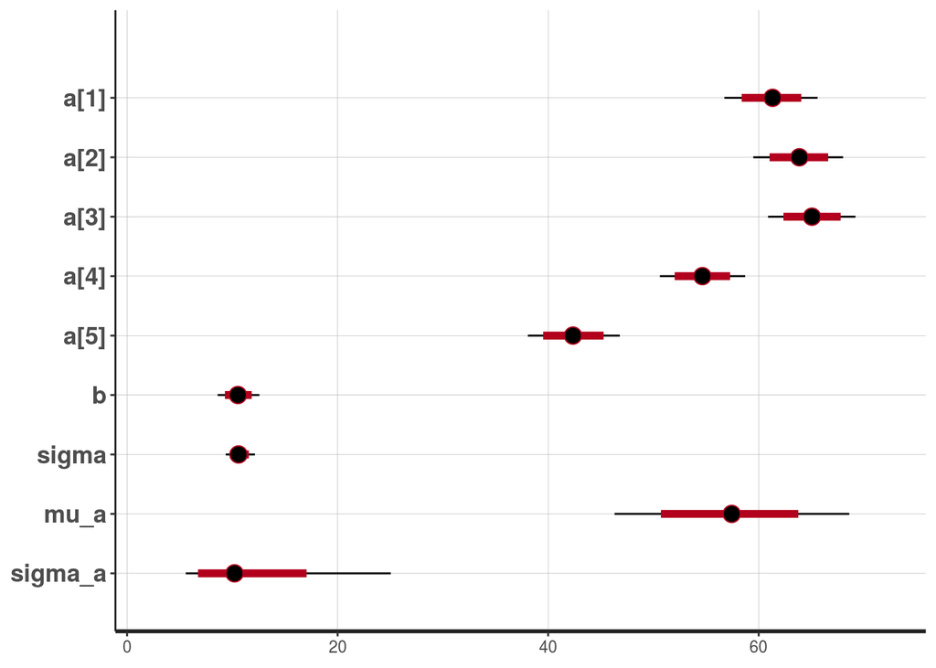

```r
plot(fit_partial)
```

```r
# plot(fit_partial, pars="a")
# plot(As.mcmc.list(fit_partial)) # from coda package

posterior=as.matrix(fit_partial)
```

As before, we can look at the individual differences of intercepts between groups (“contrasts”).

E.g., the posterior distribution of $a_4-a_5$

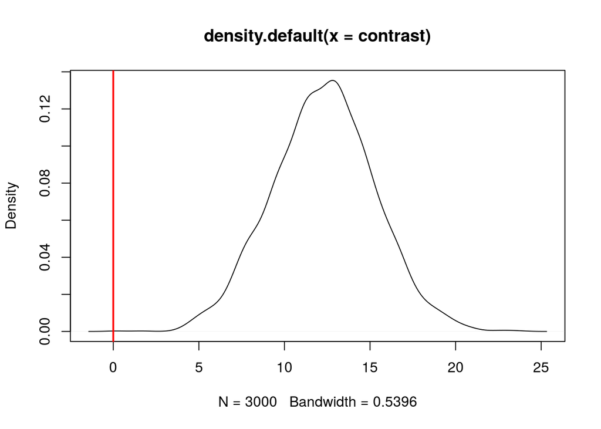

```r
contrast = posterior[,"a[4]"]-posterior[,"a[5]"]

plot(density(contrast))
abline(v=0, col="red", lwd=2)
```

# Predictions / credible intervals

Again, we can generate predictions and compute credible intervals (for the deterministic part of the model) and prediction intervals (for the data, including statistical part of the model).

(Here: 90% credible intervals)

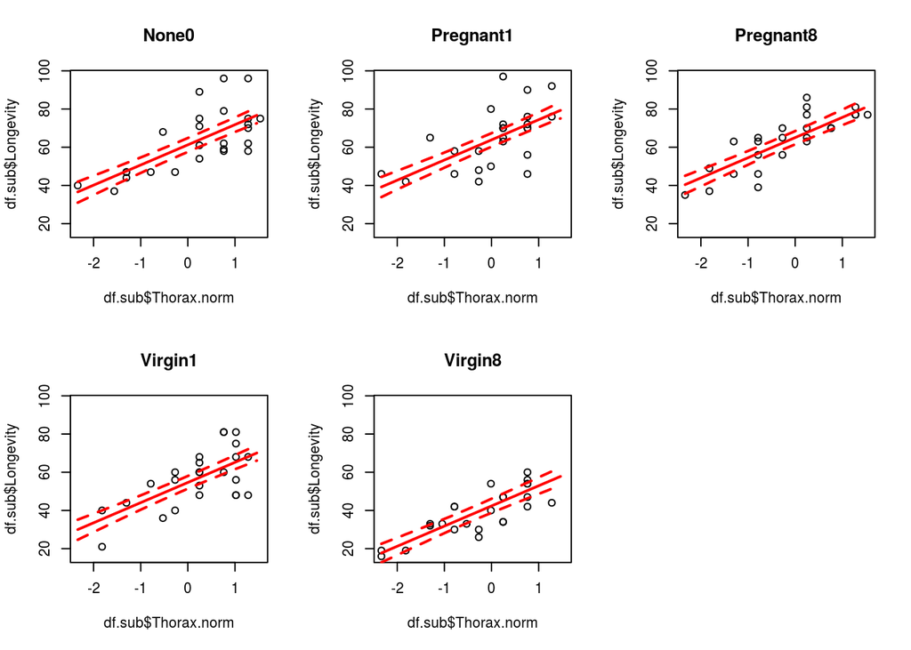

```r
x.pred = seq(from=min(df$Thorax.norm), to=max(df$Thorax.norm), by=0.1)

par(mfrow=c(2,3))

for (i in 1:5){
  df.sub=subset(df, df$group==i)
  plot(df.sub$Thorax.norm,  df.sub$Longevity,
       xlim=range(df$Thorax.norm),
       ylim=range(df$Longevity),
       main=levels(df$CompanionNumber)[i]
  )

  y.cred = matrix(0, nrow=nrow(posterior), ncol=length(x.pred))
  for(j in 1:nrow(posterior)){
    # column i in posterior corresponds to a_i, alternatively reference by name: posterior[j,paste0("a[",i,"]")]
    y.cred[j, ] = posterior[j,i] + posterior[j,"b"]*x.pred
  }

  y.cred.mean = apply(y.cred, 2, function(x) mean(x))
  lines(x.pred, y.cred.mean, col="red", lwd=2)

  y.cred.q05 = apply(y.cred, 2, function(x) quantile(x, probs=0.05))
  lines(x.pred, y.cred.q05, col="red", lwd=2, lty=2)

  y.cred.q95 = apply(y.cred, 2, function(x) quantile(x, probs=0.95))
  lines(x.pred, y.cred.q95, col="red", lwd=2, lty=2)
}
```